# Преступность в Киеве

## Общая информация о базе данных

База данных содержит информацию о 1666062 правонарушениях, совершенных в городе Киеве с 2014 по 2016 годы.

Распределение правонарушений по типам свидетельствует о достаточно несбалансированном наборе данных:

| Тип правонарушения | Количество | Частота |
| --- | --- | --- |
| ІНША ПОДІЯ | 589 035 | 0.3535 |
| ІНШІ АДМІНІСТРАТИВНІ ПРАВОПОРУШЕННЯ | 365 527 | 0.2194 |
| КРАДІЖКА | 173 903 | 0.1044 |
| ДТП БЕЗ ТРАВМОВАНИХ | 114 906 | 0.0690 |
| СІМЕЙНА СВАPКА | 52 925 | 0.0318 |
| ВТРАТА ДОКУМЕНТІВ,ПЕЧАТОК | 52 052 | 0.0312 |
| ШАХРАЙСТВО | 41 940 | 0.0252 |
| РАПТОВА СМЕРТЬ | 38 823 | 0.0233 |
| ПОВІДОМЛЕННЯ ЛІКАРЯ | 36 124 | 0.0217 |
| ДРІБНЕ ХУЛІГАНСТВО | 35 068 | 0.0210 |

[output cut: 90 more lines]

Отдельно следует отметить, что ряд правонарушений в некоторые из годов в базу не попал вообще. Так например в 2014-2015 годах отсутствуют преступления, связанные с контрабандой, в 2014 - связанные с незаконной перевозкой лиц за границу и т.д. Ввиду этого рекомендуется исключить из дальнейшего анализа правонарушения, частота которых за весь период составляет менее 1 000 случаев.

## Распределения правонарушений

Распределение количества правонарушений по месяцам свидетельствует о том, что больше преступлений совершается в теплое время года, достигая пика в июле.

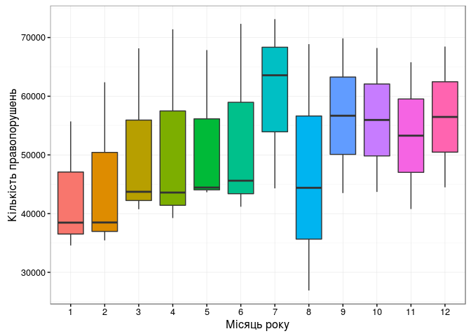

Несколько меньшее количество правонарушений происходит в выходные дни.

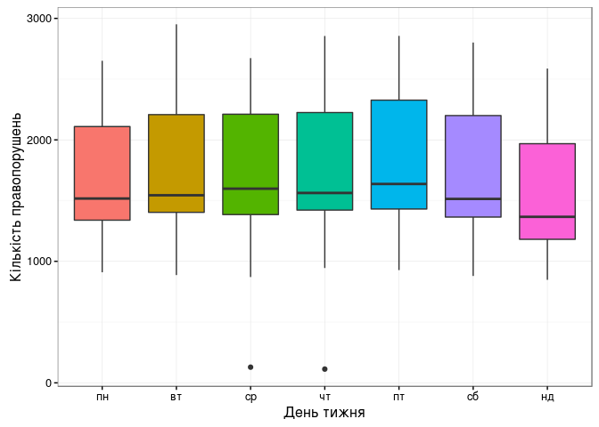

Больше всего правонарушений происходит в 10 и 12 часов дня. Ночью количество правонарушений снижается.

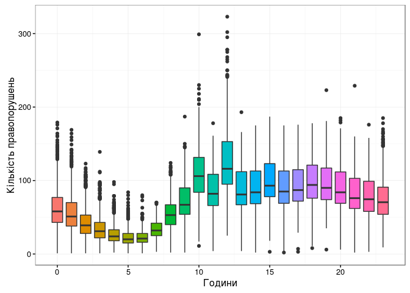

Также следует отметить, что в выходные дни значительно большее количество правонарушений приходится на ночное время.

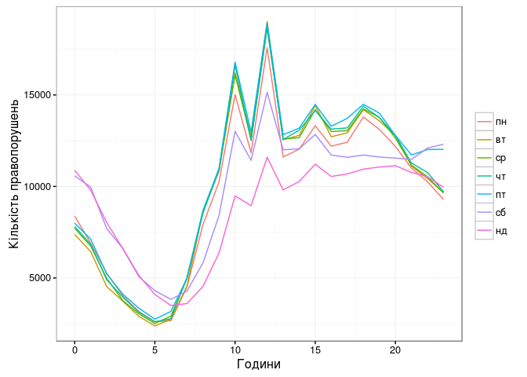

Большинство правонарушений происходит преимущественно в хорошую погоду.

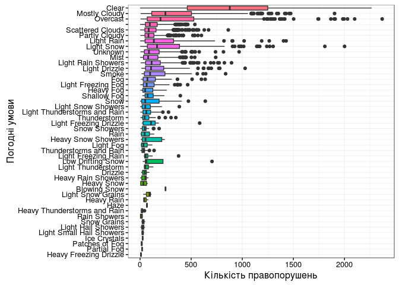

Распределение количества преступлений в зависимости температуры воздуха подтверждает гипотезу о том, что на холодное время приходится меньше преступлений.

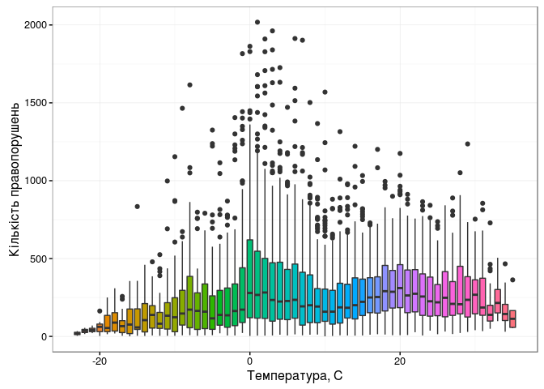

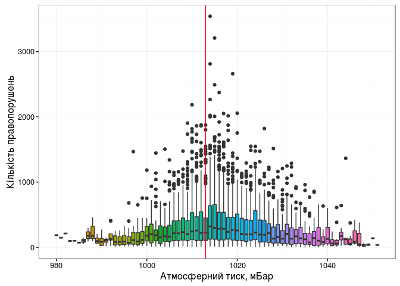

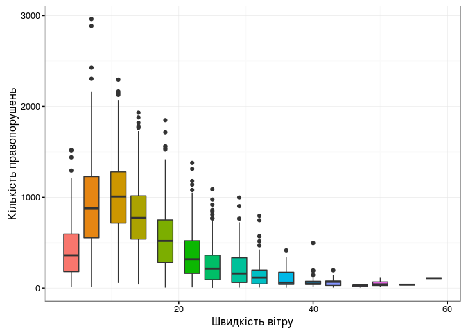

Есть также основания полагать, что уровень преступности может быть связан с ненормировано повышенной влажностью воздуха.

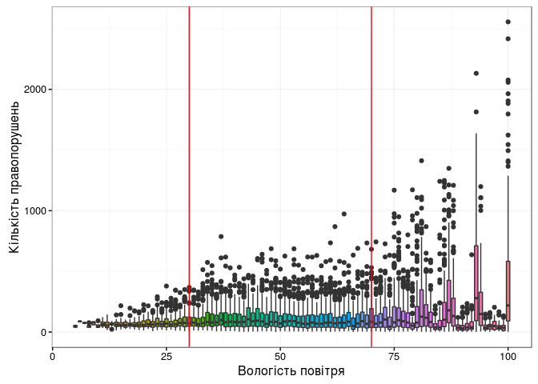

Изменение курса валют непосредственно мало влияет на совершение преступлений. Возможна необходим другой подход - например, оценка скачка курса по сравнению с предыдущим периодом, средневзвешенный курс за неделю или еще что-либо.

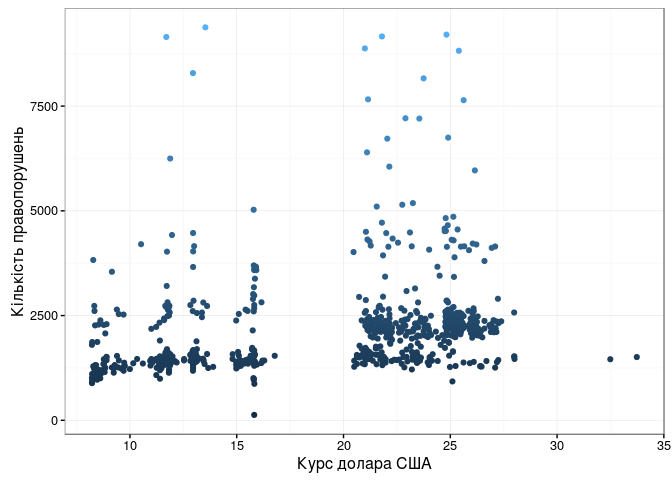

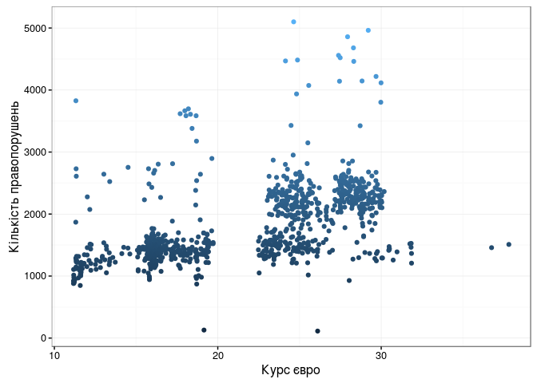

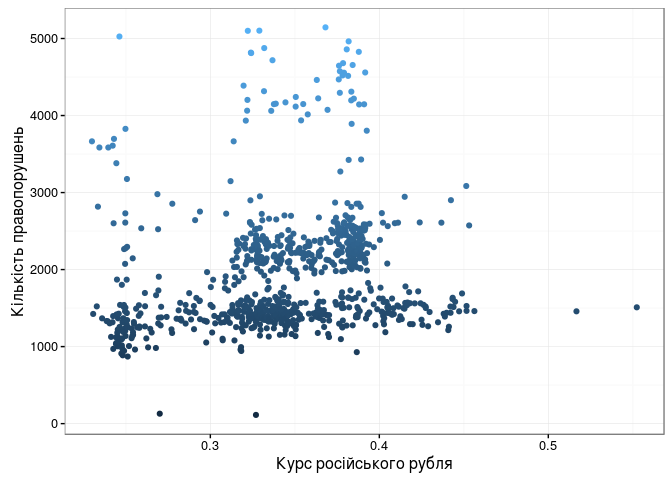

Распределение преступлений по наличию по-близости мест общественного пользования показывает, что чаще всего правонарушения происходят возле больниц, кафе, банков и банковских терминалов. Следует учесть, что это также может быть связано с количеством иест общественного пользования.

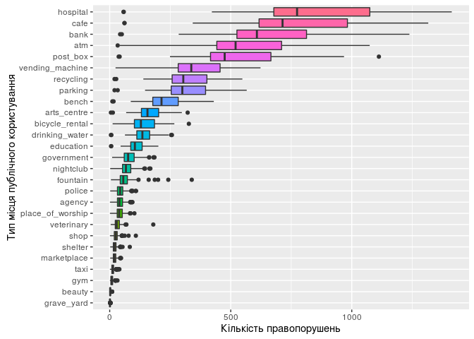

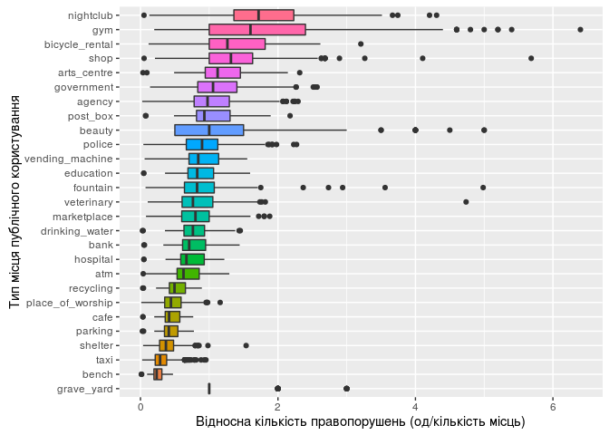

Тепловые карты показывают, что уровень преступности связан с плотностью населения. На картах нанесена выборка из 100 000 преступений.

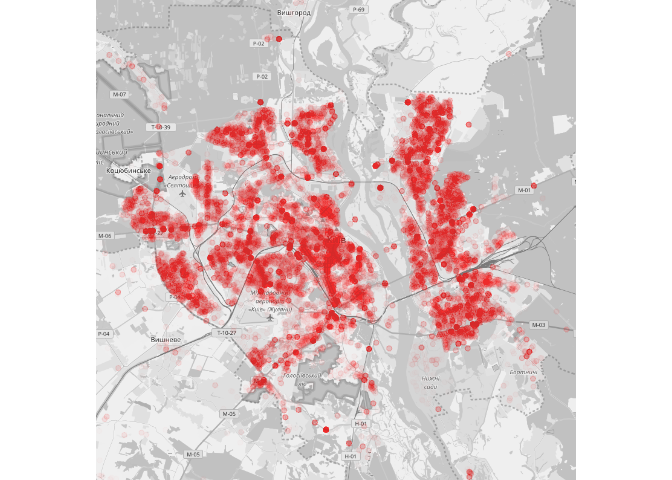

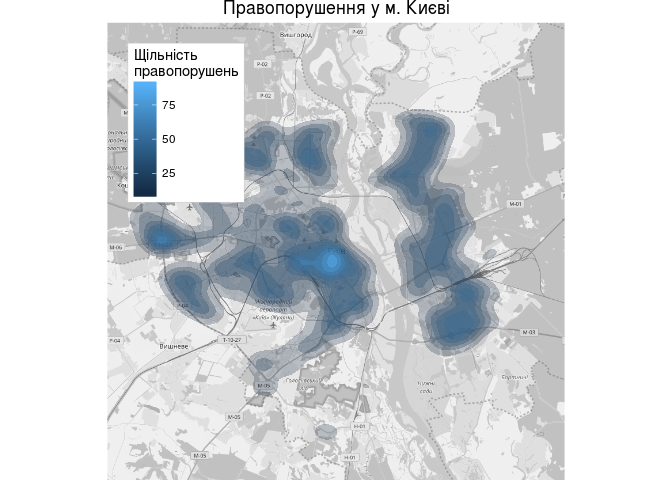